# Week 3 - Logistic Regression

This week we are doing logistic regression with a dataset that has information about portuquese sudents’ school performance. The dataset has the following columns:

```
##  [1] "school"     "sex"        "age"        "address"    "famsize"
##  [6] "Pstatus"    "Medu"       "Fedu"       "Mjob"       "Fjob"
## [11] "reason"     "nursery"    "internet"   "guardian"   "traveltime"
## [16] "studytime"  "failures"   "schoolsup"  "famsup"     "paid"
## [21] "activities" "higher"     "romantic"   "famrel"     "freetime"
## [26] "goout"      "Dalc"       "Walc"       "health"     "absences"
## [31] "G1"         "G2"         "G3"         "alc_use"    "high_use"
```

The data is a mean of two questionaires that contain the students’ performance in maths and portuquese classes. Alc_use is the average of alcohol use during week days and weekends, and high_use was defined as alc_use>2. For more information about the original datasets, see P. Cortez and A. Silva (2008)

Our aim with this dataset is to study the relationship between some of the variables and alchol consumption. Let’s hypothesize that the following variables have the following correlations with alcohol consumption:

-famrel [quality of family relationships (numeric: from 1 - very bad to 5 - excellent)] : better relationships predict smaller alcohol consumption - Fedu [father’s education (numeric: 0 - none, 1 - primary education (4th grade), 2 - 5th to 9th grade, 3 - secondary education or 4 - higher education)]: high education predicts smaller alcohol consumption -sex [student’s sex (binary: ‘F’ - female or ‘M’ - male)]: males have a higher alcohol consumption than females - absences [number of school absences (numeric: from 0 to 93)]: high number of absences correlate high alchohol use - G3 [final grade (numeric: from 0 to 20, output target)]: bad grades correlate with high alcohol consumption -

Let’s start by studying the distribution of these variables:

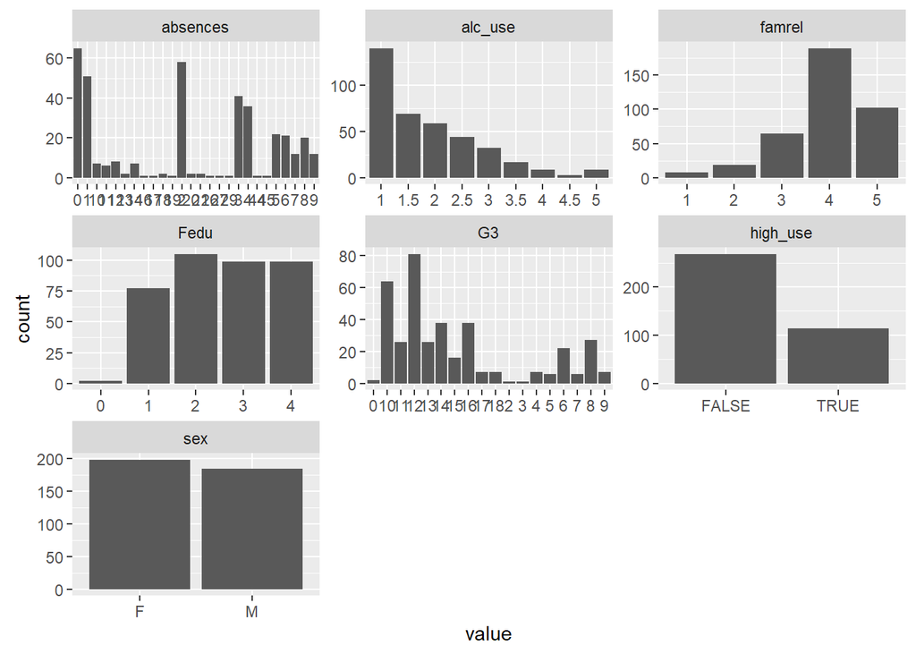

Let’s see some summary statistics

```
## Source: local data frame [4 x 7]
## Groups: sex [?]
##
##      sex high_use count mean_grade mean_absences mean_Fedu mean_famrel
##   (fctr)    (lgl) (int)      (dbl)         (dbl)     (dbl)       (dbl)
## 1      F    FALSE   156   11.39744      4.224359  2.487179    3.910256
## 2      F     TRUE    42   11.71429      6.785714  2.619048    3.761905
## 3      M    FALSE   112   12.20536      2.982143  2.633929    4.133929
## 4      M     TRUE    72   10.27778      6.125000  2.597222    3.791667
```

We can get a better understand of the variances and differences between genders by drawing boxplots

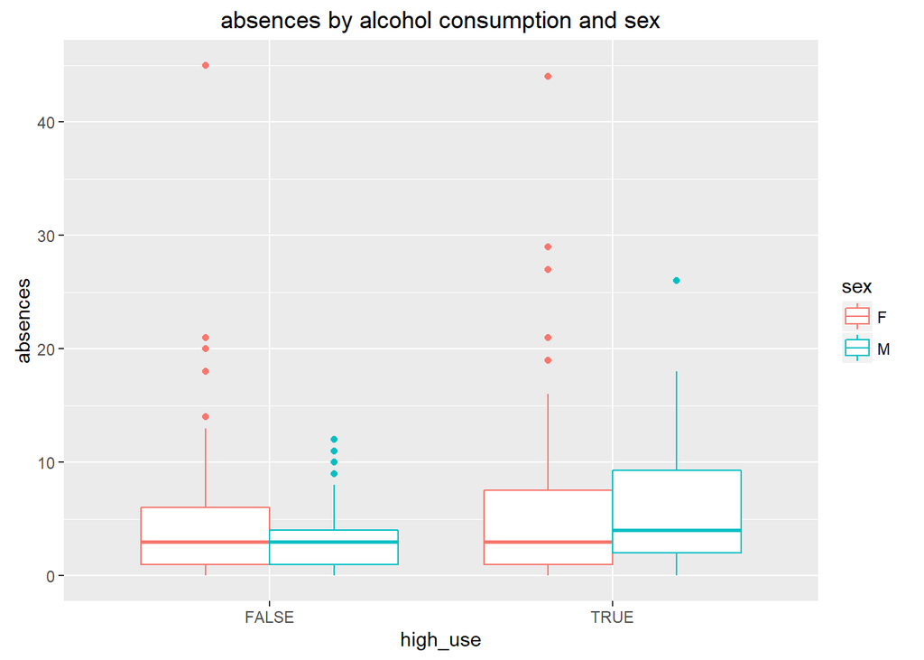

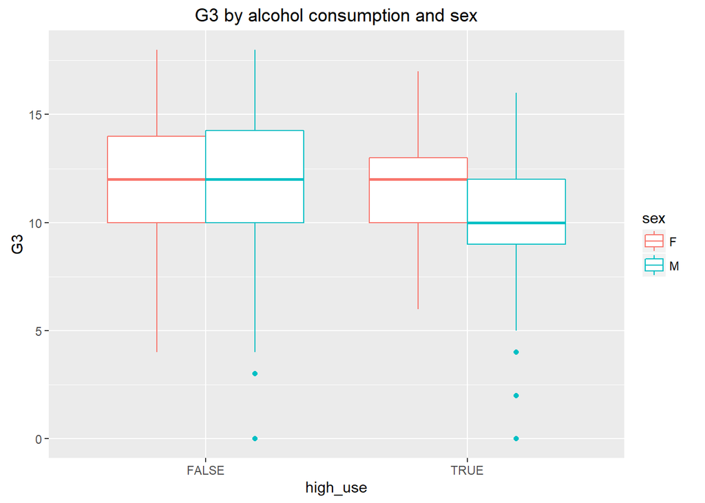

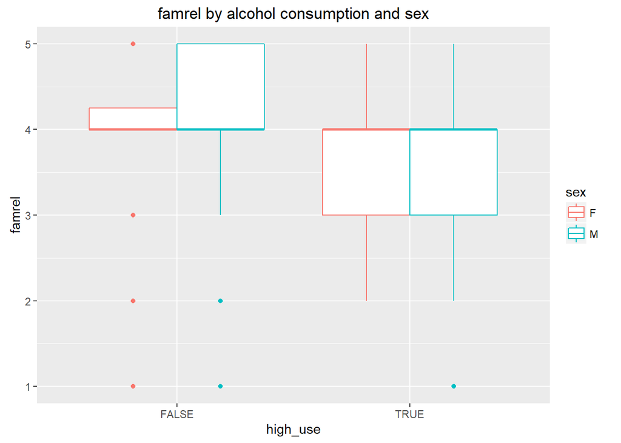

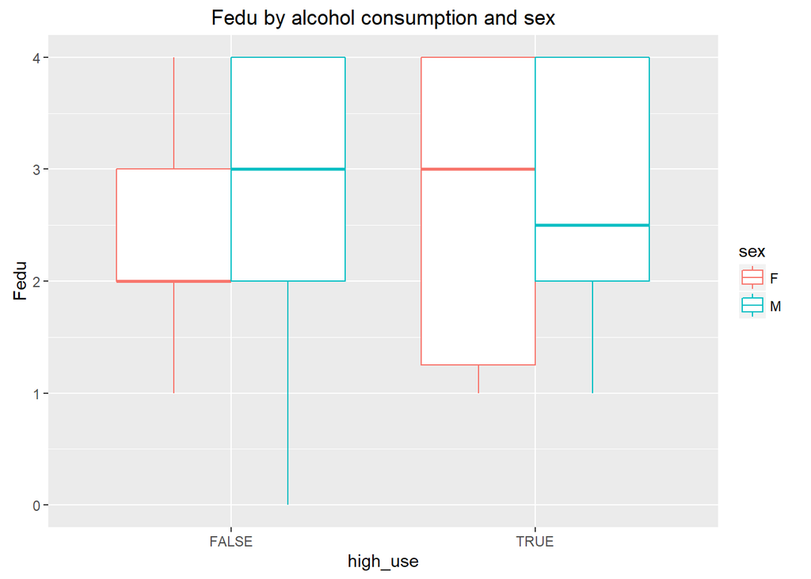

From the above visualizations we can make the following interpretations: 1) the final grades in males seem to have a relationship with alcohol consumption 2) It’s not evident from the boxplots (bad scaling), but according to summary statistics, also absences seem to have a positive correlation with alcohol consumption in both genders. 3) Alcohol consumption is higher in males than in females. 4) famrel might have slight anti-correlation with alcohol consumption 5) father’s education doesn’t affect alcohol consumption

# Logistic regression

```
FALSE
FALSE Call:
FALSE glm(formula = high_use ~ Fedu + famrel + G3 + absences + sex,
FALSE     family = "binomial", data = interesting)
FALSE
FALSE Deviance Residuals:
FALSE     Min       1Q   Median       3Q      Max
FALSE -2.1519  -0.8117  -0.6134   1.0133   2.2671
FALSE
FALSE Coefficients:
FALSE             Estimate Std. Error z value Pr(>|z|)
FALSE (Intercept) -0.02660    0.68280  -0.039   0.9689
FALSE Fedu         0.06344    0.11168   0.568   0.5700
FALSE famrel      -0.28122    0.12803  -2.197   0.0281 *
FALSE G3          -0.07714    0.03671  -2.102   0.0356 *
FALSE absences     0.08905    0.02263   3.935 8.31e-05 ***
FALSE sexM         1.02560    0.24488   4.188 2.81e-05 ***
FALSE ---
FALSE Signif. codes:  0 '***' 0.001 '**' 0.01 '*' 0.05 '.' 0.1 ' ' 1
FALSE
FALSE (Dispersion parameter for binomial family taken to be 1)
FALSE
FALSE     Null deviance: 465.68  on 381  degrees of freedom
FALSE Residual deviance: 420.38  on 376  degrees of freedom
FALSE AIC: 432.38
FALSE
FALSE Number of Fisher Scoring iterations: 4
```

```
FALSE Waiting for profiling to be done...
```

```
FALSE                    OR     2.5 %    97.5 %
FALSE (Intercept) 0.9737465 0.2528565 3.7149161
FALSE Fedu        1.0655004 0.8563864 1.3281038
FALSE famrel      0.7548620 0.5861940 0.9701893
FALSE G3          0.9257579 0.8607999 0.9944720
FALSE absences    1.0931363 1.0477981 1.1452972
FALSE sexM        2.7887688 1.7369999 4.5452140
```

Interpretation of results: 1) According to the ods ratios and their confidence intervals, students with good familyrelationships are less likely to have high alcohol consumption. 2) Students with good grades are also slightly less likely to use high amounts of alcohol. 3) high number of absences predicts slighthy higher probability for high alcohol consumption 4) males are more likely to have higher consumption than females

# Predicting alcohol consumption with our model

```
##         prediction
## high_use FALSE TRUE
##    FALSE   253   15
##    TRUE     81   33
```

```
##         prediction
## high_use      FALSE       TRUE        Sum
##    FALSE 0.66230366 0.03926702 0.70157068
##    TRUE  0.21204188 0.08638743 0.29842932
##    Sum   0.87434555 0.12565445 1.00000000
```

From the tables above we see that our model predicted quite well the cases where high_use was false (only 4 prosent were false positives). The model was not as good for predicting True cases were not predicted as effectively (20% were missed trues). The total training error is around 25%, so 75% of the cases were predicted correctly.

# References

P. Cortez and A. Silva. Using Data Mining to Predict Secondary School Student Performance. In A. Brito and J. Teixeira Eds., Proceedings of 5th FUture BUsiness TEChnology Conference (FUBUTEC 2008) pp. 5-12, Porto, Portugal, April, 2008, EUROSIS, ISBN 978-9077381-39-7